# VRA Section 2 Analysis-Los Angeles

DRAFT–Internal Use Only

5/28/2021

Initial Analysis of VRA Section 2 assessment is to check the race/ethnicity of the current county sup district to get a baseline of minority VAP/CVAP from 2010. If the minority population hasn’t decreased, then we need to at least keep the same number of minority opportunity districts as last time.

Steps

1. Get race/eth summary by sup district from 2010.
2. Compare race/eth summary from 2010 to race/eth summary from most recent estimates (2019 ACS). See what kind of population change we’ve had.
3. Determine how many minority opportunity districts you can create where the race/ethnicity share is 50%+.

## Step 1: Identify 2010 Minority Opportunity Districts

Which current LA County Supervisorial Districts had 50% or more of minority Voting Age (VAP) or Citizen Voting Age Population (CVAP) in 2010?

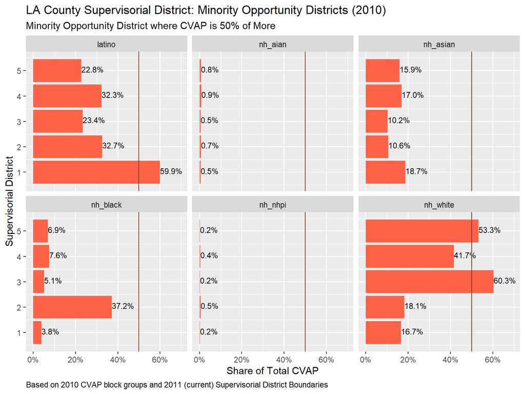

- Supervisorial District 1 (SELA/SGV) is the only district where the Latinx CVAP exceeds 50%.
- No other districts have majority minority CVAP, although District 2 (South LA) is predominately Black, with 37.2% of the CVAP (followed by Latinx with 32.7% of total CVAP).

## Step 2: Identify Population Changes from 2011

#### How has the Citizen Voting Age Population Changed?

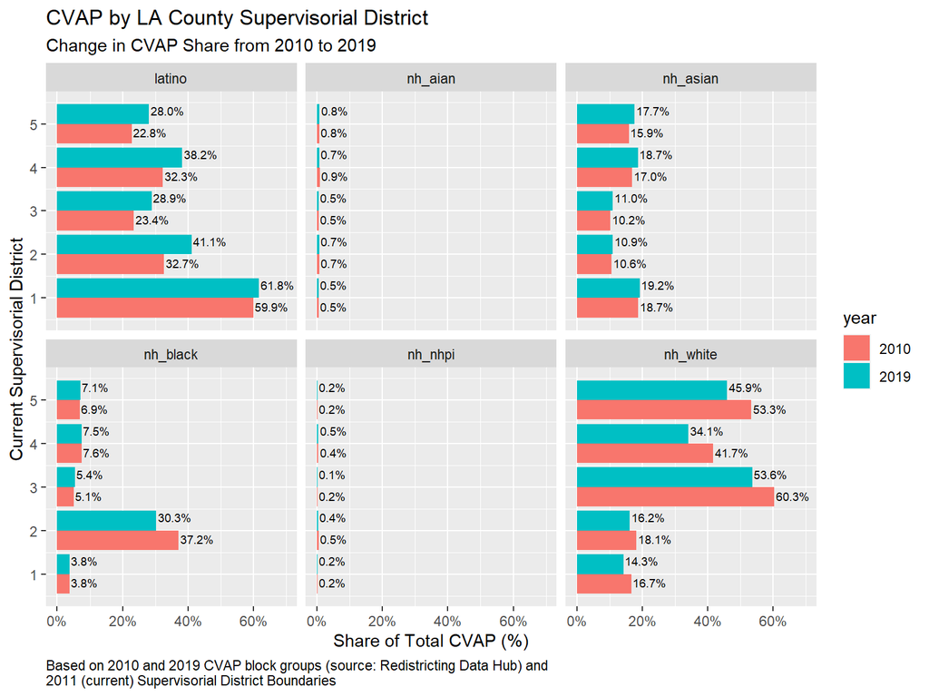

- The Latinx share of total CVAP has increased in every supervisorial district since 2010.
- The Black (non-Latinx) share of total CVAP remained steady in all districts except District 2, where it decreased.
- The Asian (non-Latinx) share of CVAP increased slightly in every supervisorial district since 2010.
- Although there was some fluctuation in CVAP over the past decade, the AIAN (non-Latinx) and NHPI (non-Latinx) share of total CVAP remained mostly steady in all districts. Neither have increased enough to allow a majority district.

#### Closer look at the changes…

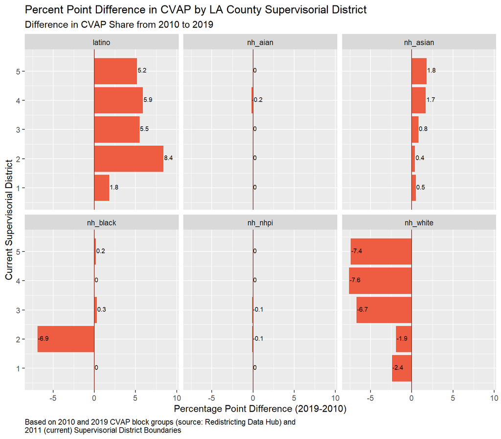

- The Latinx CVAP share increased by 8.4 percentage points in District 2, the district with the largest Latinx CVAP increase.
- The Asian CVAP share increased the most in Districts 5 and 4, by more than 1.5 percentage points in both.
- The Black CVAP share decreased by nearly 7 percentage points in District 2.

#### County CVAP Changes

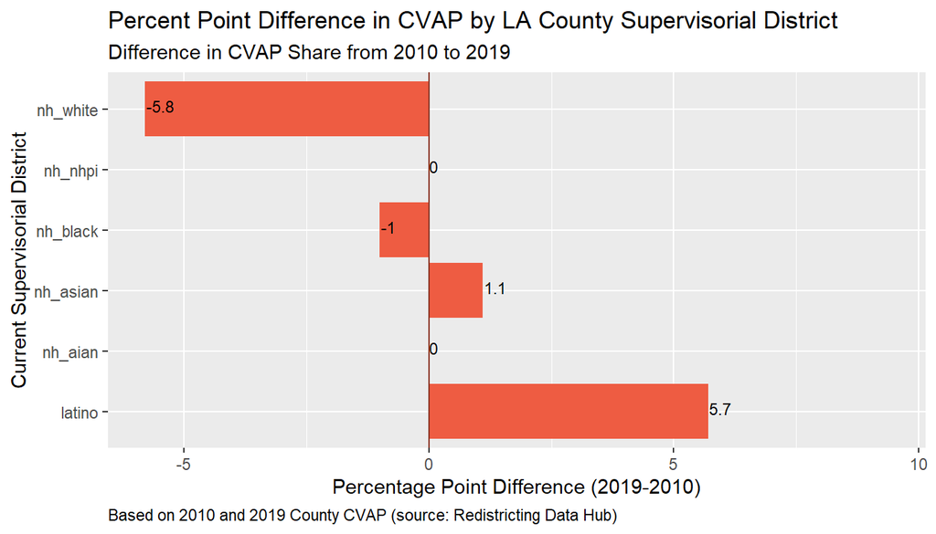

## Step 3: Given the current CVAP, how many minority opportunity districts can be created?

#### What is the ideal total population per district?

- According to the HaystaqDNA projections, the 2020 LA County population is 10,138,940.
- Dividing the LA County total population by 5 Supervisorial Districts, the ideal district population is 2,027,788.

### CVAP Summary of Draft District Plan

Supervisor District plan drafted in Maptitude. [Draft plan](https://advancementproject.sharepoint.com/:b:/s/Portal/Eb8uLEkIyehGpnvNRXOB3EABTzGlOpDOdx2KcGCKimYxBg?e=sTCGkm) can be viewed here. Do NOT share externally.

#### District 1

AV/SC/North County

| district | raceeth | CVAP_percent | CVAP_moe |
| --- | --- | --- | --- |
| 1 | latino | 32.2% | 0.41% |
| 1 | nh_aian | 0.8% | 0.02% |
| 1 | nh_asian | 16.5% | 0.12% |
| 1 | nh_black | 7.2% | 0.06% |
| 1 | nh_nhpi | 0.2% | 0.03% |
| 1 | nh_white | 42.7% | 0.32% |

- Non-Latinx white has the largest CVAP share (43%), followed by Latinx people (32%). No group has majority.
- CVAP margin of error not meaningful.

#### District 2

SELA/SGV

| district | raceeth | CVAP_percent | CVAP_moe |
| --- | --- | --- | --- |
| 2 | latino | 50.4% | 0.46% |
| 2 | nh_aian | 0.6% | 0.02% |
| 2 | nh_asian | 23.4% | 0.17% |
| 2 | nh_black | 4.8% | 0.05% |
| 2 | nh_nhpi | 0.3% | 0.06% |
| 2 | nh_white | 20.3% | 0.27% |

- Latinx CVAP share is just barely the majority at 50.4%.
- With a Latinx CVAP margin of error at 0.46%, it could potentially negate the Latinx majority.

#### District 3

SFV/SELA

| district | raceeth | CVAP_percent | CVAP_moe |
| --- | --- | --- | --- |
| 3 | latino | 53.5% | 0.44% |
| 3 | nh_aian | 0.6% | 0.02% |
| 3 | nh_asian | 13.4% | 0.10% |
| 3 | nh_black | 4.9% | 0.01% |
| 3 | nh_nhpi | 0.1% | 0.03% |
| 3 | nh_white | 27.1% | 0.31% |

- Latinx CVAP share is the majority at 53.5%.
- With a Latinx CVAP margin of error at 0.44%, it is not likely to impact the Latinx majority.

#### District 4

South LA/LB

| district | raceeth | CVAP_percent | CVAP_moe |
| --- | --- | --- | --- |
| 4 | latino | 44.6% | 0.46% |
| 4 | nh_aian | 0.7% | 0.02% |
| 4 | nh_asian | 9.4% | 0.08% |
| 4 | nh_black | 32.3% | 0.27% |
| 4 | nh_nhpi | 0.5% | 0.08% |
| 4 | nh_white | 12.1% | 0.23% |

- The Black CVAP share is at 32.3%, the district with the highest Black CVAP. The current Black CVAP in Supervisorial District 2 is 30%, so this is a slight increase in CVAP share.
- Latinx CVAP is the largest share of CVAP (44.6%), though not a majority.
- CVAP margin of error not meaningful.

#### District 5

West LA/Coastal

| district | raceeth | CVAP_percent | CVAP_moe |
| --- | --- | --- | --- |
| 5 | latino | 17.3% | 0.32% |
| 5 | nh_aian | 0.6% | 0.02% |
| 5 | nh_asian | 14.2% | 0.10% |
| 5 | nh_black | 5.3% | 0.05% |
| 5 | nh_nhpi | 0.2% | 0.04% |
| 5 | nh_white | 61.9% | 0.31% |

- Non-Latinx white has a majority CVAP at 61.9%.

## Sources/References:

- (LA County Legal Considerations)[https://www.google.com/url?sa=t&rct=j&q=&esrc=s&source=web&cd=&cad=rja&uact=8&ved=2ahUKEwiYmdHxyO3wAhXFl54KHRJoDi8QFjAAegQIBRAD&url=http%3A%2F%2Ffile.lacounty.gov%2FSDSInter%2Fbos%2Fsupdocs%2F59570.pdf&usg=AOvVaw103KyrNp2M6LKrGwQNCION]
- (Public Mapping)[http://www.publicmapping.org/what-is-redistricting/redistricting-criteria-the-voting-rights-act]